# assignment1

nikunjgoel

### Exercise 1

**Install R and RStudio (optional) now.**

I installed R and RStudio

### Exercise 2

**Install xts and consequently zoo now.**

```r
library(xts)
```

### Exercise 3

**Install the most recent version of astsa from Github.**

```r
library(astsa)
```

### Exercise 4

**Explain what you get if you do this: ( 1 : 20 / 10 ) %% 1**

```r
(1:20/10)%%1
```

```
##  [1] 0.1 0.2 0.3 0.4 0.5 0.6 0.7 0.8 0.9 0.0 0.1 0.2 0.3 0.4 0.5 0.6 0.7 0.8 0.9
## [20] 0.0
```

‘1:20’ Gave us 20 numbers starting with 1 and ending at 20 with an increment of 1.  
‘/10’ Divided all the 20 numbers with 10  
‘%% 1’ Gave us a remainder of when dividing by 1.

### Exercise 5

**Verify that 1/ i = − i where i = √ − 1 .**

```r
1/1i
```

```
## [1] 0-1i
```

Answer is 0-1i which is of the form $a + bi$  
So b is -1.

### Exercise 6

```r
exp(1i*pi)
```

```
## [1] -1+0i
```

### Exercise 7

**Calculate these four numbers: cos ( π /2 ) , cos ( π ) , cos ( 3 π /2 ) , cos ( 2 π ) .**

```r
cosseq <- ( pi * 1 : 4 / 2 )
cos(cosseq)
```

```
## [1]  6.123234e-17 -1.000000e+00 -1.836970e-16  1.000000e+00
```

### Exercise 8

**What is the difference between these two lines? 0 = x = y 0-> x-> y**

```r
0=x=y
0->x->y
```

It gives an error on the first statement and second statement says $x = 0$ and $y = 0$. $=$ does not support left side assignments.

### Exercise 9

**Why was y+z above the vector (10, 7, 4) and why is there a warning?**

```r
x = c ( 1 , 2 , 3 , 4 ); y = c ( 2 , 4 ); z = c ( 8 , 3 , 2 )
y + z
```

```
## Warning in y + z: longer object length is not a multiple of shorter object
## length
```

```
## [1] 10  7  4
```

Because y is just 2 elements and z is 3 elements.  
interpreter added 2 + 8 and 4+3. For the last element in Z it looped y array again.

### Exercise 10

**Create a directory that you will use for the course and use the tricks previously mentioned to make it your working directory (or use the default if you don’t care). Load astsa and use help to find out what’s in the data file cpg . Write cpg as text to your working directory.**

```r
library(astsa)
?cpg
write(cpg,file ='zzz.txt',ncolumns=1)
```

### Exercise 11

Find the file zzz.txt previously created (leave it there for now). Solution: In RStudio , use the Files tab. Otherwise, go to your working directory: getwd ()

### Exercise 12

Scan and view the data in the file zzz.txt that you previously created.

```r
(cost_per_gig = scan("zzz.txt"))
```

```
##  [1] 2.13e+05 2.95e+05 2.60e+05 1.75e+05 1.60e+05 7.10e+04 6.00e+04 3.00e+04
##  [9] 3.60e+04 9.00e+03 7.00e+03 4.00e+03 2.00e+03 9.50e+02 8.65e+02 2.59e+02
## [17] 1.03e+02 6.29e+01 2.45e+01 1.25e+01 6.41e+00 2.68e+00 1.57e+00 1.38e+00
## [25] 6.70e-01 5.30e-01 4.20e-01 2.70e-01 7.00e-02
```

### Exercise 13

Make two vectors, say a with odd numbers and b with even numbers between 1 and 10. Then, use cbind to make a matrix, say x from a and b . Afterthat, display each column of x separately.

```r
a = seq(1,10,by=2)
b = seq(2,10,by=2)
x <- cbind(a,b)
x[,1]
```

```
## [1] 1 3 5 7 9
```

```r
x[,2]
```

```
## [1]  2  4  6  8 10
```

### Exercise 14

Generate 100 standard normals and draw a boxplot of the results when there are at least two displayed outliers (keep trying until you get two).

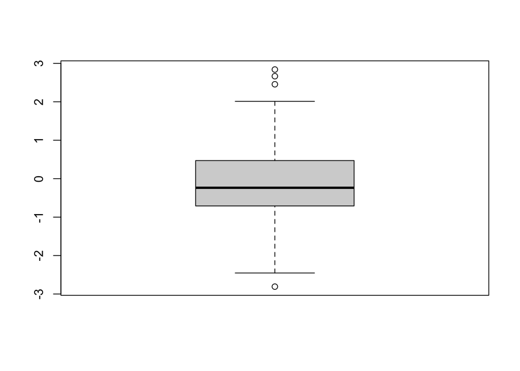

```r
set.seed(911)
boxplot(rnorm(100))
```

### Exercise 15

Write a simple function to return, for numbers x and y , the first input raised to the power of the second input, and then use it to find the square root of 25.

```r
exercise15 <- function(x,y){x^y}
exercise15(25,0.5)
```

```
## [1] 5
```

### Exercise 16

Add red horizontal and vertical dashed lines to the previously generated graph to show that the fitted line goes through the point (x,y).

```r
set.seed(666)
x = rnorm(10)
y = 1 + 2*x + rnorm(10)
summary(fit <- lm(y~x))
```

```
##
## Call:
## lm(formula = y ~ x)
##
## Residuals:
##      Min       1Q   Median       3Q      Max
## -1.22799 -1.01300  0.05943  0.60401  2.32480
##
## Coefficients:
##             Estimate Std. Error t value Pr(>|t|)
## (Intercept)   1.0680     0.3741   2.855 0.021315 *
## x             1.6778     0.2651   6.330 0.000225 ***
## ---
## Signif. codes:  0 '***' 0.001 '**' 0.01 '*' 0.05 '.' 0.1 ' ' 1
##
## Residual standard error: 1.18 on 8 degrees of freedom
## Multiple R-squared:  0.8336, Adjusted R-squared:  0.8128
## F-statistic: 40.07 on 1 and 8 DF,  p-value: 0.0002254
```

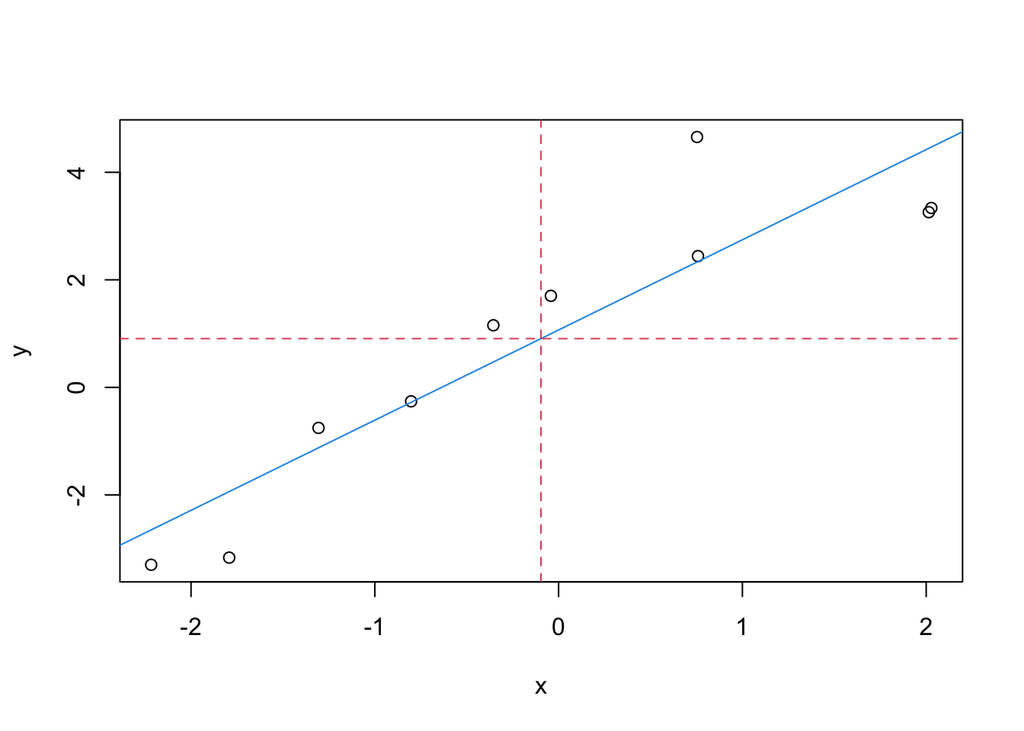

```r
plot(x,y)
abline(fit, col=4)
abline ( h = mean ( y ), col = 2 , lty = 2 )
abline ( v = mean ( x ), col = 2 , lty = 2 )
```

### Exercise 17

Rerun the previous example of mortality on pollution but without making a data frame.

```r
part4 <- lag(part,-4)
summary(fit <- lm(cmort ~ part + part4, na.action = NULL))
```

```
##
## Call:
## lm(formula = cmort ~ part + part4, na.action = NULL)
##
## Residuals:
##     Min      1Q  Median      3Q     Max
## -21.609  -6.328  -0.626   5.385  36.253
##
## Coefficients: (1 not defined because of singularities)
##             Estimate Std. Error t value Pr(>|t|)
## (Intercept) 74.79860    1.30943   57.12   <2e-16 ***
## part         0.29317    0.02631   11.14   <2e-16 ***
## part4             NA         NA      NA       NA
## ---
## Signif. codes:  0 '***' 0.001 '**' 0.01 '*' 0.05 '.' 0.1 ' ' 1
##
## Residual standard error: 8.969 on 506 degrees of freedom
## Multiple R-squared:  0.197,  Adjusted R-squared:  0.1954
## F-statistic: 124.2 on 1 and 506 DF,  p-value: < 2.2e-16
```

### Exercise 18

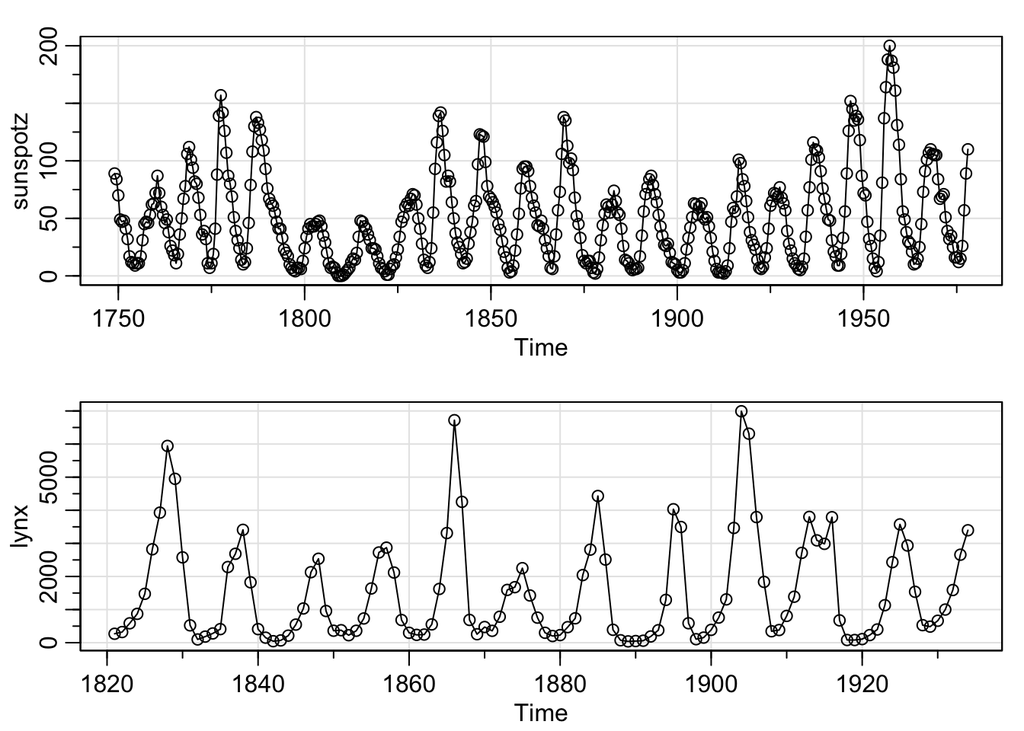

```r
par(mfrow=c(2,1))
tsplot(sunspotz, type="o")
tsplot(lynx, type="o")
```